# login: Shiny Login Module

This package provides a framework for adding user authentication to [Shiny](https://shiny.posit.co) applications. This is unique to other authentication frameworks such as [ShinyManager](https://datastorm-open.github.io/shinymanager/) and [shinyauthr](https://github.com/PaulC91/shinyauthr?tab=readme-ov-file) in that it provides tools for users to create their own accounts and reset passwords. This is particularly useful for Shiny applications used to collect data without a pre-existing user management system. User credentials are stored in any database that supports the [DBI](https://dbi.r-dbi.org) interface. Passwords are hashed using MD5 in the browser so that unencrypted passwords are never available to the Shiny server. For an extra layer of security, you can salt the password before storing it in the database.

## Installation

You can download the latest development version using the `remotes` package:

```r
remotes::install_github('jbryer/login')
```

## Getting Started

There is a template located at [`login_template/app.R`](https://github.com/jbryer/login/blob/main/inst/login_template/app.R) that demonstrates the basic functionality. You can copy-and-paste this template for starting a new Shiny application with authentication. The following sections will describe the various functions required for the authentication to work.

## Shiny Server

The `login_server()` function handles all the server side functionality and must be added to your Shiny server function. The following examples provides the basic functionality using a SQLite database and a basic SMTP email server.

```r
APP_ID <- 'my_login_app' # It is recommended that this is defined in global.R
```

```r
library(login)
```

```r
USER <- login::login_server(
    id = APP_ID,
    db_conn = RSQLite::dbConnect(RSQLite::SQLite(), 'users.sqlite'),
    emailer = emayili_emailer(
        email_host = email_host,
        email_port = email_port,
        email_username = email_username,
        email_password = email_password,
        from_email = reset_password_from_email
    ),
    additional_fields = c('first_name' = 'First Name',
                          'last_name' = 'Last Name'),
    cookie_name = 'loginusername',
    salt = APP_ID
)
```

The `APP_ID` must be a unique identifier for the Shiny module. It is possible to have more than one `login` module per Shiny application. For this example, we are only using one and it is important to use the same ID for all server and UI components.

The `login_server()` returns a `shiny::reactiveValues()` object with two elements you can use: `logged_in` which is TRUE if the user is logged in or FALSE otherwise and `username` which contains the username when logged in.

The `db_conn` parameter can take any database connection from the [`DBI` R package](https://dbi.r-dbi.org).

The `emailer` parameter is a function with three parameters: `to_email`, `subject`, and `message`. The `emayili_emailer` is a helper function that wraps the [`emayili` R package](https://datawookie.github.io/emayili/) for sending emails through SMTP. The source code for this function is included below to serve as a template for wrapping other methods of sending email.

```r
emayili_emailer <- function(
        email_host = NULL,
        email_port = NULL,
        email_username = NULL,
        email_password = NULL,
        from_email = NULL
) {
    function(to_email, subject, message) {
        email <- emayili::envelope() |>
            emayili::from(from_email) |>
            emayili::to(to_email) |>
            emayili::subject(subject) |>
            emayili::text(message)
        smtp <- emayili::server(
            email_host,
            email_port,
            email_username,
            email_password
        )
        smtp(email, verbose = FALSE)
    }
}
```

The `additional_fields` is a character vector defining other data that will be collected when users create an account. These data are not used by the `login` package but will be stored in the users table (defined by the `users_table` parameter). The values will be used as the input labels and the names will the column names.

The `salt` parameter defines an extra layer encryption for storing the passwords in the database. At minimum, passwords are hashed using a MD5 algorithm. More details are provided below.

## Shiny UI

On the UI side only the `login_ui()` function is required. This will create a login box. This will also ensure the JavaScript and CSS assets are loaded to ensure the password is encrypted client size. It is important that you use the same `id` across all `login` functions.

```r
login::login_ui(id = APP_ID)
```

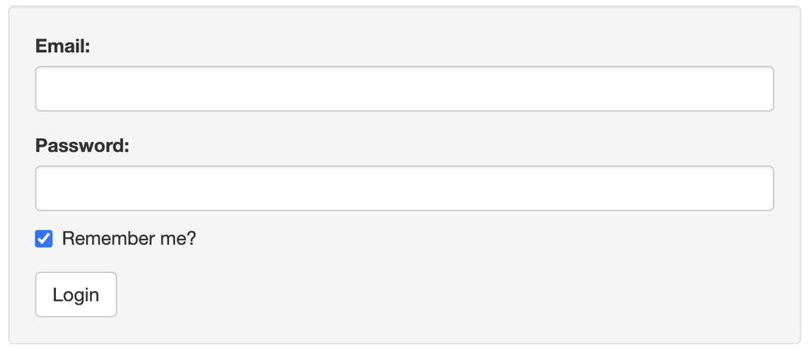

Screenshot for logging in

To add a log out button use the `logout_button()` function. This will only display if you are logged in. You can customize the button using the `label`, `icon`, and `style` parameters which are passed to the `shiny::actionButton()` function.

```r
login::logout_button(id = APP_ID)
```

Optionally, you can write your logout procedure by setting `USER$logged_in <- FALSE` in the server logic.

The `new_user_ui()` function will provide an interface for users to create a new account. If the `emailer` parameter is set for `login_server()` and `verify_email = TRUE` then users will need to verify their email address before the account is created. This is done by sending a code (six digits by default) to the email address that they need to enter.

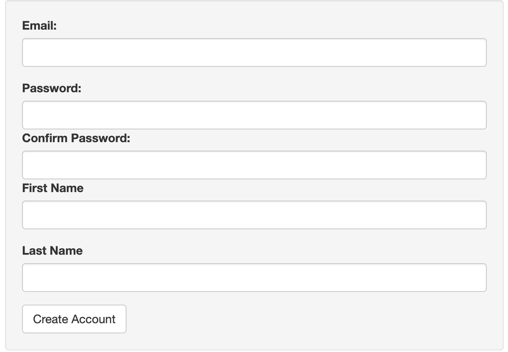

Screenshot for creating a new account

The `reset_password_ui()` function provides UI elements for users to reset their password. This requires that the `emailer` parameter has been set for the `login_server()` function. Users enter their email address and request a code. Once the code has been sent the UI will changed asking the user to enter the code emailed to them. If they enter the correct code they can then enter a new password.

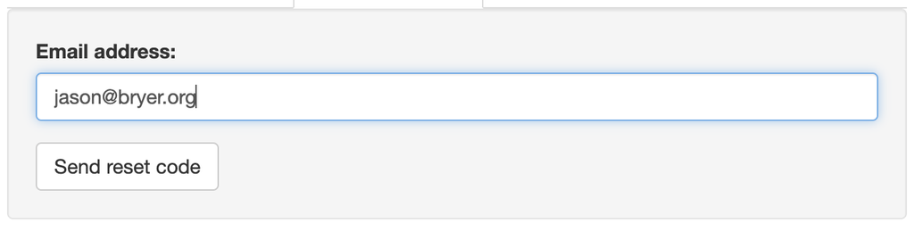

Screenshot of step one for resetting a password

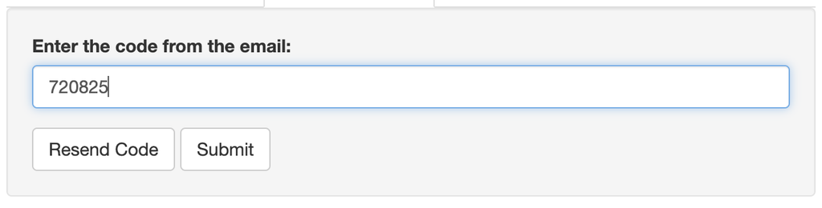

Screenshot of step two for resetting a password

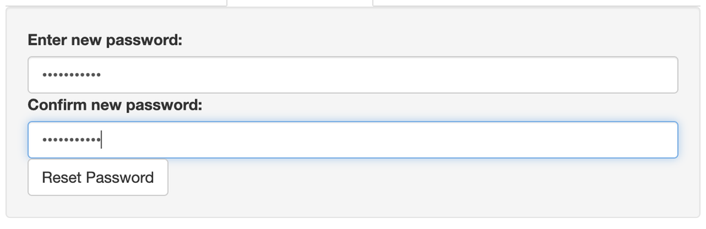

Screenshot of step three for resetting a password

## Adapting your Shiny application to the user

On the server side you check the value of `USER$logged_in`, for example, if you are rendering UI components on the server use the following pattern:

```r
output$my_ui <- renderUI({
  if(USER$logged_in) {
    # UI elements visible to users who are logged in.
  } else {
    # UI elements visible to users who are NOT logged in.
  }
})
```

On the UI side, the `is_logged_in()` and `is_not_logged_in()` functions allow you encapsulate Shiny UI elements so they are only visible when the user is or is not logged in, respectively.

```r
login::is_logged_in(
  id = APP_ID,
  div("This only shows when you are logged in!")
)
```

```r
login::is_not_logged_in(
  id = APP_ID,
  div("This only shows when you are NOT logged in!")
)
```

## Salting

Salting is the process of adding an additional input to the hash to guard against attacks using precomputed tables of passwords. The `login_server()` function has two parameters to control salting: the `salt` parameter defines the word or phrase that will be concatenated to the password and `salt_algo` defines the algorithm used to encrypt the password (by default the `sha512` algorithm will be used). The `digest::digest()` function is used and you can consult the documentation for details on the hashing algorithms.

```r
password <- "test"
salt <- APP_ID
```

The password is hashed using the md5 algorithm by the browser before being sent to the Shiny server. Without specifying a salt, this is the password that would be stored in the database.

```r
password_md5 <- digest::digest(password, algo = 'md5', serialize = FALSE)
```

However, sense we specified a salt, the following hash is what will be stored in the database.

```r
paste0(salt, password_md5) |> digest::digest(algo = 'sha512', serialize = FALSE)
```

```
#> [1] "d86d29e1c61ec2fb11debbc1ea9b260f73d94a1e044964bd62eede36cbe99136c92431a0269555df7399cc939aa8f9a4364daa23d3c21f838f0d309f62ce3913"
```

Although the password is encrypted client side it is recommended that you configure your Shiny server to use https. This can be done using Posit’s enterprise solutions or configure Shiny server behind another webserver such as [nginx](https://www.nginx.com).

## User management outside of the `login` module

One of the primary motivating factors for creating this package was to have an authentication framework where users can create and manage their own accounts. However, it is possible to use only the login feature and manage users through your own custom code. However, it will require hashing the password before storing in the database. The following command using the `digest::digest()` function will produced the same hash as the MD5 algorithm run in the users browser. If you wish to salt the passwords an additional step will be required as described in the salting section above.

```r
password_md5 <- digest::digest(password, algo = 'md5', serialize = FALSE)
```

## Acknowledgements

This package relies on the work of [Huidong Tian](https://github.com/withr) who wrote the JavaScript code to hash the passwords client side. The original code is available here: https://gist.github.com/withr/9001831

## Disclaimer

I am not a security expert. I have made every effort to use the best practices as I understand them. I highly recommend deploying your application using https (e.g. use nginx and letsencrypt) to ensure all communication between the client and server are encrypted. Any issues or concerns can be filed as a Github issue. Use at your own risk.